# Нейронные сети

©ilykei.com., Balasanov Yu.,Doynikov A.,Nazarov L.

06 october 2023 г

# Нейронные сети

Нейронная сеть это математическая модель построенная исходя из принципов функционирования головного мозга и представляет собой систему взаимодействующих между собой искусственных нейронов.Каждый нейрон имеет дело только с сигналами, которые он периодически получает, и сигналами, которые он периодически посылает другим нейронам. Нейронные сети позволяют решать статистические задачи классификации, кластеризации, прогнозирования временных рядов, задачи распознавания образов, моделирования естественного интеллекта.

Главное приемущество нейронных систем это возможность обучения, которое заключается в постепенном (в процессе обучения) оценке коэффициента связи с другими нейронами сети.

По построению нейронные сети можно поделить на однонаправленные, когда сигнал передается со слоя на слой последовательно, и на сети, где есть петли обратной связи. Однонаправленные сети гарантированно закончат свою работу. Поведение сетей с обратной связью, вообоще говоря, непредсказуемо. В этом случае следует принимать специальные меры к тому, чтобы сеть не зацикливалась.

Исторически первые появились сети на основе перцептрона - кибернетическая модель мозга, предложенной Фрэнком Розенблаттом в 1957 году.Перцептрон состоит из трёх типов элементов, а именно: поступающие от сенсоров сигналы передаются ассоциативным элементам, а затем реагирующим элементам.Чтобы «научить» перцептрон классифицировать образы, был разработан специальный итерационный метод обучения проб и ошибок, напоминающий процесс обучения человека — метод коррекции ошибки.

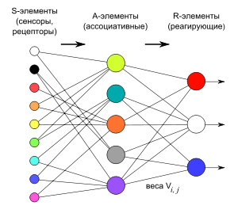

Логическая схема перцептрона представлена на рисунке.

Поступающая через вход информация обрабатывается в нейроне в 2 этапа: На первом этапе вычисляется взвешенная сумма:
$$S = \sum_{i=1}^n\omega_i X_i + O$$
Число О — порог.

Обычно, для унификации записи порог рассматривается как вес тупой связи, то есть связи которая все время генерирует 1. И тогда можно записать как:
$$S = \sum_{i=0}^n\omega_i
X_i$$

где
$$X_0 = 1, \omega_0 = O$$
Это так называемый классический нейрон сокращенно КН.

В обобщённом КН выступают вероятностные меры, где число О — случ. величина чаше всего с нормальным распределением $N(0, G)$

Алгебраический нейрон это нейрон, где сумма S нелинейна.

Выход нейрона — $Y$. определяется как некоторая функция от взвешенной суммы.
$$y = f(s)$$
Функция $f$ — функция активации.

## Примеры функций активации

1.Простая кусочно-линейная функция. Если входное значение меньше порогового, то значение функции активации равно минимальному допустимому, иначе – максимально допустимому.

2.Несложная кусочно-линейная функция. Имеет два линейных участка, где функция активации тождественно равна минимально допустимому и максимально допустимому значению и есть участок, на котором функция строго монотонно возрастает.

3.Сигмоидальная функция или сигмоид.

Монотонно возрастающая всюду дифференцируемая S-образная нелинейная функция с насыщением. Сигмоид позволяет усиливать слабые сигналы и не насыщаться от сильных сигналов. Примером сигмоидальной функции активации может служить логистическая функция, задаваемая следующим выражением:
$$f(s)=\frac{1}{1+e^{-\alpha s}}$$

Еще одним примером сигмоидальной функции активации является гиперболический тангенс, задаваемый следующим выражением:
$$f(s)=tanh(s)=\frac{e^s-e^{-s}}{e^s+e^{-s}}$$
график которого

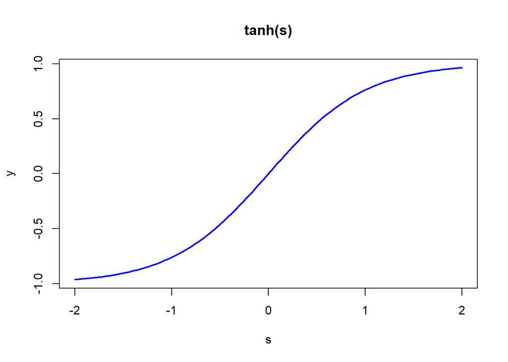

```r
s <- seq(-2, 2, length.out = 101)
y <- tanh(s)
plot(s,y,col= "blue",type = "l",main = "tanh(s)",lwd = 2)
```

В практических задач почти всегда применяется сигмоидальная функция активации.

## Обучение сети

Алгоритмы обучения бывают с учителем и без. Алгоритм называется алгоритмом с учителем, если при обучении известны и входные, и выходные вектора сети. Имеются пары вход + выход — известные условия задачи и решение. В процессе обучения сеть меняет свои параметры и учится давать нужное отображение $Y= f(x)$. Сеть учится давать результаты, которые нам уже известны. За счет способности к обобщению сетью могут быть получены новые результаты, если подать на вход вектор, который не встречался при обучении.

Перцептрон обучается с учителем. Это означает, что должно быть задано множество пар векторов вход-выход $x_s,d_s$ $x_s$ — формализованное условие задачи, а $d_s$ — известное решение для этого условия. Совокупность пар $x_s,d_s$,составляет обучающее множество. $S$ — количество элементов в обучающем множестве — должно быть достаточным для обучения сети,чтобы под управлением алгоритма сформировать набор параметров сети, дающий нужное отображение $Y= f(x)$. Количество пар в обучающем множестве не регламентируется. Если элементов слишком много или мало, сеть не обучится и не решит поставленную задачу. Выберем один из векторов $x_s$ x и подадим его на вход сети. На выходе получится некоторый вектор $y_s$ . Тогда ошибкой сети можно считать
$$E =||y_s − d_s||$$
y для каждой пары $x_s,d_s$. Чаще всего для оценки качества обучения выбирают суммарную квадратическую ошибку:
$$E= \sum_{s,j}(d_{s,j}-y_{s,j})^2$$
Общая схема обучения перцептрона: 1. Инициализировать веса и параметры функции активации в малые ненулевые значения;

2. Подать на вход один образ и рассчитать выход;
3. Посчитать ошибку $E_s$, сравнив $d_s$ и $y_s$.
4. Изменить веса и параметры функции активации так, чтобы ошибка $E_s$ уменьшилась.
5. Повторить шаги 2-4 до тех пор, пока ошибка не перестанет убывать или не станет достаточно малой.

Если множество всех весов обозначим через $\Omega$, а множество всех пороговых значений через $\Theta$, то задача поиска
$$min_{\Omega,\Theta}E(\Omega,\Theta)$$
, является задачей безусловной оптимизации. Для ее решения известно множество методов . В теории оптимизации функция ошибки $E(\Omega,\Theta)$ называется целевой функцией. Для нейронных сетей хорошо работают многие методы безусловной оптимизации, часто лучше, чем узкоспециальные, придуманные для обучения нейронных сетей. Применяются следующие методы теории оптимизации:

1. для небольшого количества параметров — стабилизированные методы Ньютона, Гаусса-Ньютона, Левенберга,Маркардта;
2. для среднего количества параметров — квазиньютоновские методы;
3. для большого количества параметров — метод сопряженных градиентов.

## Обучение однослойного перцептрона

Задача обучения однослойного перцептрона решается просто. Его работа определяется выражением:
$$S_j= \sum_{i}
\omega_{i,j} x_{i,j}$$
$$y_j=F(S_j-\Theta_j)$$
Подадим на вход один вектор $x$ из обучающего множества. Рассчитаем выход и сравним полученный выходной вектор $y$ с эталоном $d$ . Зная разницу между ними, можно ввести коррекции для весовых коэффициентов и пороговых уровней:
$$\Delta\omega_j= \epsilon(y_j-d_j)x_j$$
$$\Delta\theta_j=
-\epsilon(y_j-d_j)x_j$$
где $\epsilon$ — небольшое положительное число, характеризующее скорость обучения.

## Булевы функции

Приведем примеры реализации и обучения однослойных перцептронов, реализующих булевы функции AND и OR.

### Функция OR

Cоздадим простейшие пример для функции OR.

```r
(da<-data.frame(x1=c(0,0,1,1),x2=c(0,1,0,1),y=c(0,1,1,1)))
```

```
##   x1 x2 y
## 1  0  0 0
## 2  0  1 1
## 3  1  0 1
## 4  1  1 1
```

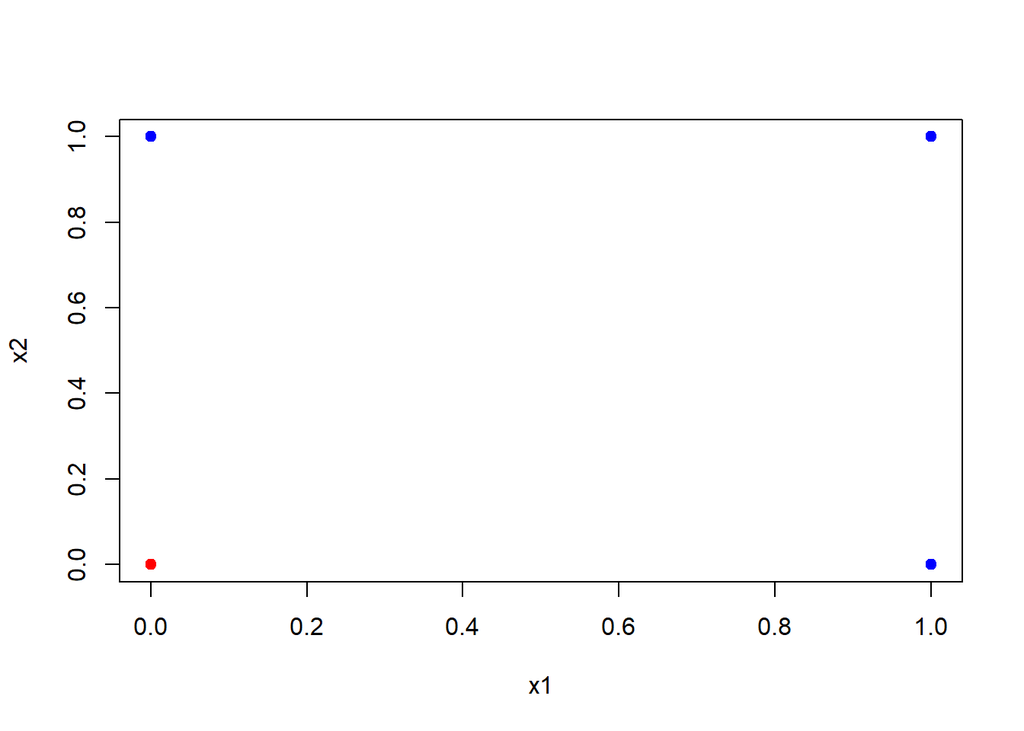

```r
plot(subset(da,y==1)[,1:2],pch=19,col="blue")
points(subset(da,y==0)[,1:2],pch=19,col="red")
```

```r
library(boot)
library(neuralnet)
set.seed(14)
nnDa <- neuralnet(y~x1+x2,data=da, err.fct="sse",rep=2)
names(nnDa)
```

```
##  [1] "call"                "response"            "covariate"
##  [4] "model.list"          "err.fct"             "act.fct"
##  [7] "linear.output"       "data"                "exclude"
## [10] "net.result"          "weights"             "generalized.weights"
## [13] "startweights"        "result.matrix"
```

```r
print(nnDa)
```

```
## $call
## neuralnet(formula = y ~ x1 + x2, data = da, rep = 2, err.fct = "sse")
##
## $response
##   y
## 1 0
## 2 1
## 3 1
## 4 1
##
## $covariate
##      x1 x2
## [1,]  0  0
## [2,]  0  1
## [3,]  1  0
## [4,]  1  1
##
## $model.list
## $model.list$response
## [1] "y"
##
## $model.list$variables
## [1] "x1" "x2"
##
##
## $err.fct
## function (x, y)
## {
##     1/2 * (y - x)^2
## }
## <bytecode: 0x00000000072b2358>
## <environment: 0x00000000072b0bf0>
## attr(,"type")
## [1] "sse"
##
## $act.fct
## function (x)
## {
##     1/(1 + exp(-x))
## }
```

[output cut: 104 more lines]

```
##
##
## $result.matrix
##                                [,1]          [,2]
## error                  0.0002478762  0.0009504074
## reached.threshold      0.0039233994  0.0034301613
## steps                 89.0000000000 43.0000000000
## Intercept.to.1layhid1 -2.2360570180 -0.9557604235
## x1.to.1layhid1         5.9314312771  4.1351192315
## x2.to.1layhid1         5.9692212313  4.2741937305
## Intercept.to.y        -0.1034243712 -0.3900286578
## 1layhid1.to.y          1.1209353689  1.4251036444
##
## attr(,"class")
## [1] "nn"
```

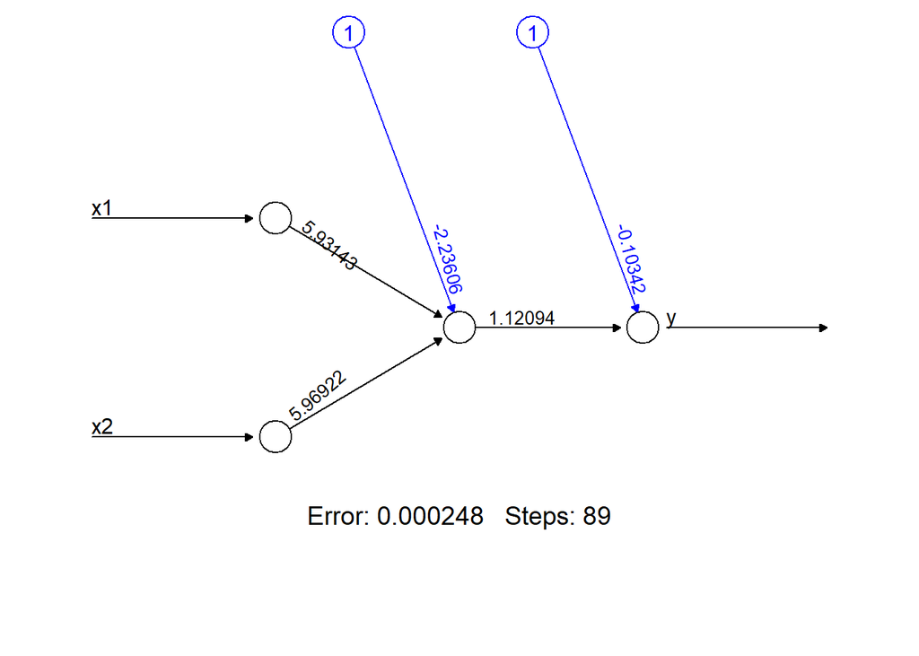

```r
plot(nnDa,rep="best")
```

По умолчанию в методе neuralnet() используется логистическая функция.

$$f(u)=\frac{1}{1+exp(−u)}$$

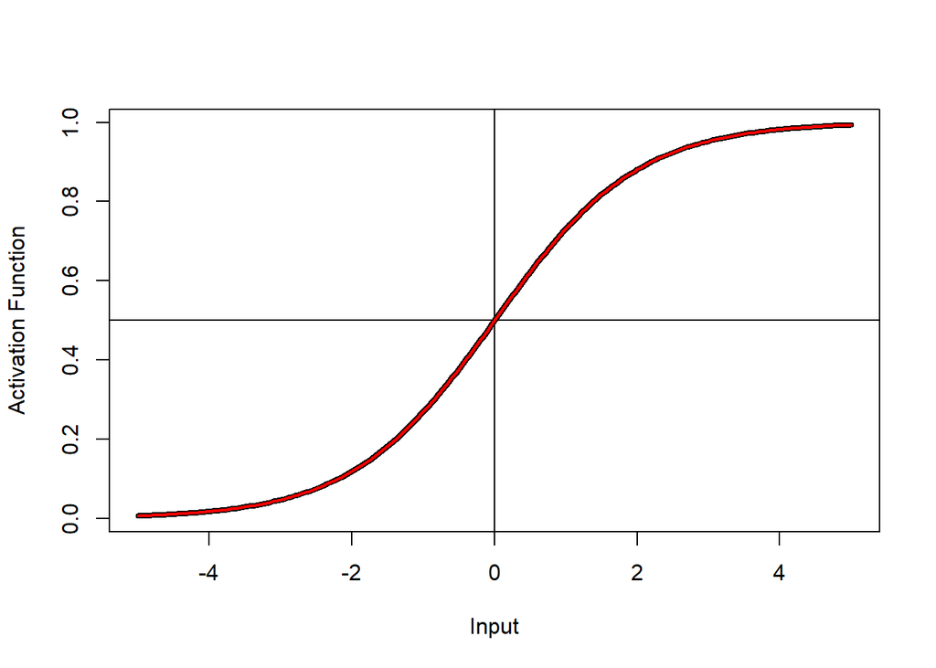

```r
vr<-seq(from=-5,to=5,by=.05)
plot(vr,nnDa$act.fct(vr),type="l",ylab="Activation Function",xlab="Input",lwd=4)
abline(v=0)
abline(h=.5)
lines(seq(from=-5,to=5,by=.05),1/(1+exp(-vr)),col="red",lwd=2)
```

Для задания функции активации в виде гиперболического тангенса необходимо задать параметр act.fct=‘tanh’.

Посмотрим на результат обучения. Поле result.matrix выходного объекта содержит всю необходимую информацию полученную при обучении.

```r
nnDa$result.matrix
```

```
##                                [,1]          [,2]
## error                  0.0002478762  0.0009504074
## reached.threshold      0.0039233994  0.0034301613
## steps                 89.0000000000 43.0000000000
## Intercept.to.1layhid1 -2.2360570180 -0.9557604235
## x1.to.1layhid1         5.9314312771  4.1351192315
## x2.to.1layhid1         5.9692212313  4.2741937305
## Intercept.to.y        -0.1034243712 -0.3900286578
## 1layhid1.to.y          1.1209353689  1.4251036444
```

В net.result находим оцененный выход $y_j=f(x_j)$ при обучении. В переменной weights $\omega_1,...\omega_n$ находим веса и константы $\omega_0$.

```r
nnDa$net.result
```

```
## [[1]]
##             [,1]
## [1,] 0.004811985
## [2,] 0.991327770
## [3,] 0.990343813
## [4,] 1.017439832
##
## [[2]]
##             [,1]
## [1,] 0.005762287
## [2,] 0.985275874
## [3,] 0.978142212
## [4,] 1.034249789
```

```r
nnDa$weights
```

```
## [[1]]
## [[1]][[1]]
##           [,1]
## [1,] -2.236057
## [2,]  5.931431
## [3,]  5.969221
##
## [[1]][[2]]
##            [,1]
## [1,] -0.1034244
## [2,]  1.1209354
##
##
## [[2]]
## [[2]][[1]]
##            [,1]
## [1,] -0.9557604
## [2,]  4.1351192
## [3,]  4.2741937
##
## [[2]][[2]]
##            [,1]
## [1,] -0.3900287
## [2,]  1.4251036
```

Воспроизведем в ручную выводные результаты из net.result используя оцененные коэффициенты сети.

Используем лучшую попытку. Сначала определим какая попытка лучшая

```r
repBest<-which.min(nnDa$result.matrix[1,])
repBest
```

```
## [1] 1
```

и для нее получим веса, вычислим вручную логистичекую функцию и для сравнения выведем результаты из net.result

```r
weightsX<-nnDa$weights[[repBest]][[1]][-1]
matrX<-as.matrix(da[,1:2])
manualOutput<-inv.logit(matrX%*%weightsX+nnDa$weights[[repBest]][[1]][1])*nnDa$weights[[repBest]][[2]][2]+
  nnDa$weights[[repBest]][[2]][1]
cbind(manualOutput=manualOutput,NnetOutput=nnDa$net.result[[repBest]])
```

```
##             [,1]        [,2]
## [1,] 0.004811985 0.004811985
## [2,] 0.991327770 0.991327770
## [3,] 0.990343813 0.990343813
## [4,] 1.017439832 1.017439832
```

```r
compute(nnDa,da[,1:2])
```

```
## $neurons
## $neurons[[1]]
##        x1 x2
## [1,] 1  0  0
## [2,] 1  0  1
## [3,] 1  1  0
## [4,] 1  1  1
##
## $neurons[[2]]
##      [,1]       [,2]
## [1,]    1 0.09655896
## [2,]    1 0.97664163
## [3,]    1 0.97576383
## [4,]    1 0.99993651
##
##
## $net.result
##             [,1]
## [1,] 0.004811985
## [2,] 0.991327770
## [3,] 0.990343813
## [4,] 1.017439832
```

## Задача регрессии. Прогноз результатов ЕГЭ. Библиотека neuralnet

Теперь построим регрессионную модель зависимости результата ЕГЭ по математике от результата письменного экзамена, общего числа набранных баллов и результата контрольных работ по алгебре и геометрии.

```r
set.seed(20)
filename<- './KP11.csv'

Students <-read.csv(file = filename,sep = ";")
#Students <-read.csv("./KP11ANOVA.csv",sep = ",")
DVIStud <-Students[Students$Summa> 0,]
head(DVIStud)
```

```
##   Code    Family       Name       Father Group Summa DVI EGE Task.1 X Task.2
## 1  105  АХМЕТОВА     ГЮЗЕЛЬ   РАФАЭЛЕВНА   102   489 100 100      3 1      3
## 3  234  САМСОНОВ     СЕРГЕЙ ВЛАДИМИРОВИЧ   110   495 100 100      3 1      3
## 4  358  СТЕПАНЮК АЛЕКСАНДРА     ОЛЕГОВНА   115   436  80  90      3 1      3
## 5  184 НИКИФОРОВ  ВЛАДИСЛАВ ВАЛЕНТИНОВИЧ   114   393  75  81      3 1      3
## 6  146  ХАБИРОВА    ЭЛЬВИРА   РАДМИРОВНА   103   435 100  85      2 1      3
## 8  319    КОЗЛОВ     НИКИТА ВЯЧЕСЛАВОВИЧ   117   448 100  85      3 1      3
##   X.1 Task.3а X.2 Task.3б X.3 Task.4 X.4 Task.5 X.5 Task.6 X.6 Task.7 X.7
## 1   1       3   1       3   1      3   1      3   1      3   1      2   1
## 3   1       3   1       3   1      3   1      3   1      2   1      0   0
## 4   1       3   1       3   1      3   1      3   1      2   1      0   0
## 5   1       3   1       3   1      2   1      3   1      3   1      2   1
## 6   1       3   1       3   1      2   1      3   1      2   1      3   1
## 8   1       3   1       3   1      3   1      2   1      3   1      3   1
##   Task.8 X.8 SumKP1 AlgKP1 X.A.KP1 GeomKP1 X.Г.KP1
## 1      3   1     26      6  100.0%       3  100.0%
## 3      3   1     23      6  100.0%       2   66.7%
## 4      3   1     23      6  100.0%       2   66.7%
## 5      1   0     23      6  100.0%       2   66.7%
## 6      2   1     23      6  100.0%       3  100.0%
## 8      0   0     23      6  100.0%       2   66.7%
```

Делим всю выборку на две части в случайном порядке. Обучающая часть содержит 90% всех наблюдений, а контрольная 10%.

```r
set.seed(100)
d = sort(sample(nrow(DVIStud), nrow(DVIStud)*.9))
train <- DVIStud[d,]
train <- as.data.frame(train)
test<-DVIStud[-d,]
```

Нормируем обучающую и контрольную части.

```r
egada<-data.frame(x1=train$AlgKP1/max(train$AlgKP1),x2=train$GeomKP1/max(train$GeomKP1),x3 = train$Summa/max(train$Summa),x4=train$DVI/max(train$DVI),y=train$EGE/max(train$EGE))
head(egada)
```

```
##   x1        x2        x3   x4    y
## 1  1 1.0000000 0.9819277 1.00 1.00
## 2  1 0.6666667 0.9939759 1.00 1.00
## 3  1 0.6666667 0.8755020 0.80 0.90
## 4  1 0.6666667 0.7891566 0.75 0.81
## 5  1 1.0000000 0.8734940 1.00 0.85
## 6  1 0.6666667 0.9779116 1.00 0.98
```

```r
testda<-data.frame(x1=test$AlgKP1/max(test$AlgKP1),x2=test$GeomKP1/max(test$GeomKP1),x3 = test$Summa/max(test$Summa),x4= test$DVI/max(test$DVI))
head(testda)
```

```
##          x1  x2        x3   x4
## 1 1.0000000 1.0 0.9161554 1.00
## 2 1.0000000 1.0 1.0000000 1.00
## 3 0.8333333 0.5 0.9222904 0.85
## 4 0.8333333 1.0 0.9406953 1.00
## 5 0.8333333 0.5 0.9447853 0.90
## 6 0.8333333 0.5 0.9938650 1.00
```

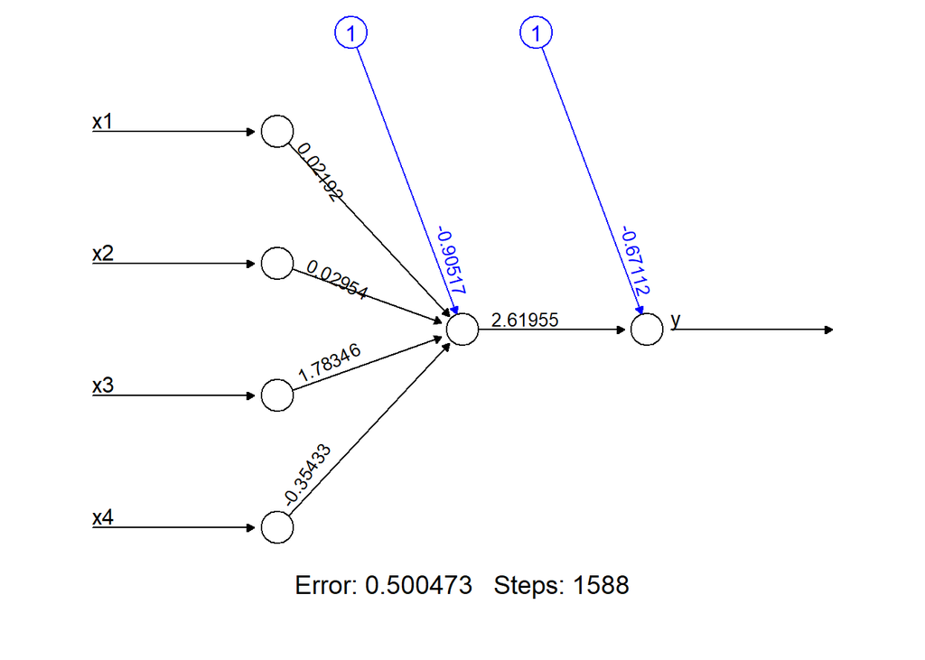

```r
library(neuralnet)
my.net <- neuralnet(y~x1+x2+x3+x4, data = egada,err.fct="sse",rep=2)
plot(my.net,rep="best")
```

```r
my.net$result.matrix
```

```
##                                [,1]          [,2]
## error                  5.009797e-01    0.50047307
## reached.threshold      9.409452e-03    0.00955558
## steps                  1.121000e+03 1588.00000000
## Intercept.to.1layhid1 -1.582033e+00   -0.90516851
## x1.to.1layhid1         3.697944e-02    0.02191683
## x2.to.1layhid1         4.554060e-02    0.02954017
## x3.to.1layhid1         2.668681e+00    1.78345558
## x4.to.1layhid1        -5.295721e-01   -0.35433313
## Intercept.to.y        -1.296947e-01   -0.67112276
## 1layhid1.to.y          1.733353e+00    2.61955409
```

И для сравнения 2 попытки обучения перцептрона со скрытым уровнем.

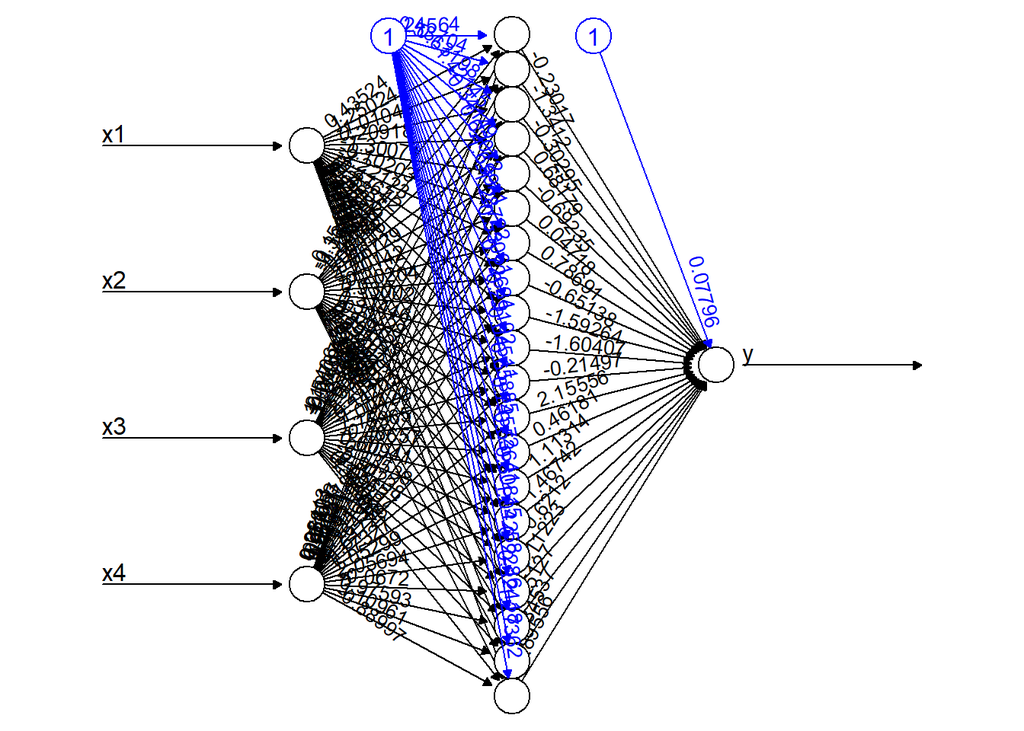

```r
my.net1 <- neuralnet(y~x1+x2+x3+x4, data = egada,hidden= 20,err.fct="sse",rep=2)
plot(my.net1,rep="best")
```

```r
my.net1$result.matrix
```

```
##                                 [,1]          [,2]
## error                    0.482977808   0.477960568
## reached.threshold        0.009592785   0.008594678
## steps                  707.000000000 527.000000000
## Intercept.to.1layhid1   -1.635785337   1.245636492
## x1.to.1layhid1          -1.531538297   0.435244630
## x2.to.1layhid1           0.215207577  -0.154272529
## x3.to.1layhid1           2.807933985  -2.540595323
## x4.to.1layhid1           0.061785645   0.284127720
## Intercept.to.1layhid2   -1.057796030  -0.537037218
## x1.to.1layhid2          -0.431117266   1.250237585
## x2.to.1layhid2           1.880578469  -0.361905745
## x3.to.1layhid2          -0.729116621   1.197666500
## x4.to.1layhid2          -0.507253660   0.652210299
## Intercept.to.1layhid3   -0.468786786   0.631978930
## x1.to.1layhid3           0.408148880  -1.010449224
## x2.to.1layhid3           0.469981133  -1.752546850
## x3.to.1layhid3          -0.508833088  -0.010847553
## x4.to.1layhid3          -1.926503400   0.261007501
## Intercept.to.1layhid4    1.880775086  -1.421453590
## x1.to.1layhid4          -1.299331774   0.209175402
## x2.to.1layhid4          -0.441751418  -0.488970746
## x3.to.1layhid4           0.198281812   1.014210678
## x4.to.1layhid4           0.256409193  -0.510526121
## Intercept.to.1layhid5   -1.230126391  -0.341487125
## x1.to.1layhid5           0.371167028  -1.300705746
## x2.to.1layhid5           0.748363459   1.094163535
## x3.to.1layhid5           0.489050544  -0.658052501
## x4.to.1layhid5           1.157830731  -0.729874041
## Intercept.to.1layhid6   -0.896600808   0.620722618
## x1.to.1layhid6          -0.069694708  -0.102033091
## x2.to.1layhid6           0.968559859  -0.967285829
## x3.to.1layhid6           0.531699922   1.333741693
## x4.to.1layhid6           0.688122848   0.966212679
## Intercept.to.1layhid7    1.075894652  -1.699409463
## x1.to.1layhid7          -0.508661798  -2.221232813
## x2.to.1layhid7           0.753441547   4.201416577
## x3.to.1layhid7          -0.832257210  -1.609711360
## x4.to.1layhid7          -0.552974973  -1.612469517
## Intercept.to.1layhid8    0.277094793  -1.287217581
```

[output cut: 70 more lines]

```
## 1layhid6.to.y            1.395507790   0.047183317
## 1layhid7.to.y           -0.545044449   0.786914795
## 1layhid8.to.y           -0.121830430  -0.651375262
## 1layhid9.to.y            1.288500076  -1.592635504
## 1layhid10.to.y          -0.079661062  -1.604067215
## 1layhid11.to.y          -0.419619445  -0.214971736
## 1layhid12.to.y           1.016858675   2.155559633
## 1layhid13.to.y          -0.432496591   0.461810862
## 1layhid14.to.y           1.214642321   1.113141485
## 1layhid15.to.y          -0.336941406   1.467420739
## 1layhid16.to.y           0.569725313  -0.621195598
## 1layhid17.to.y          -2.685464416   0.112229474
## 1layhid18.to.y          -1.399287310   0.512695624
## 1layhid19.to.y           3.294382207   0.345365351
## 1layhid20.to.y          -1.162897165  -1.895555190
```

```r
dim(testda)
```

```
## [1] 33  4
```

```r
#testda <- as.data.frame(testda)
testres <- compute(my.net,testda,rep = 1)
test1 <- cbind(test$Family,test$EGE,data.frame(netEGE =testres$net.result[,1]*max(test$EGE)))
cor(test$EGE,testres$net.result[,1]*max(test$EGE))
```

```
## [1] 0.8510993
```

Также проделаем для второй попытки обучения для сети со скрытым уровнем

```r
testres1 <- compute(my.net1,testda,rep = 2)
test2 <- cbind(test$Family,test$EGE,data.frame(netEGE =testres1$net.result[,1]*max(test$EGE)))
cor(test$EGE,testres1$net.result[,1]*max(test$EGE))
```

```
## [1] 0.7294239
```

Перцептрон со скрытым уровнем дает корреляцию прогноза меньше, чем без скрытого уровня. Посмотрим результаты прогноза ЕГЭ

```r
test1
```

```
##       test$Family test$EGE    netEGE
## 1          КОЗЛОВ       85  91.46295
## 2     БЕЛОБОРОДОВ      100 100.50662
## 3       БАЙКАЛОВА       90  94.21921
## 4           БОБОК       98  93.91016
## 5          БАГАЕВ       85  95.58612
## 6         ЖАДАНОВ      100  98.71897
## 7        ВОРОБЬЁВ       92  94.23860
## 8        КОЛЕСОВА       96  89.58355
## 9         ШЕРГИНА       87  97.64025
## 10       ЧЕРКАШИН      100  97.77113
## 11        КАЗАКОВ       94  94.03856
## 12        КЛИМЧУК       96  96.73545
## 13          ТИТОВ      100  95.82658
## 14       ПОЛУШКИН       83  91.10914
```

[output cut: 19 more lines]

Попробуем решить эту же задачу, но с помощью линейной регресссии.

```r
my.lm <- lm(y~x1+x2+x3+x4, data = egada)
summary(my.lm)
```

```
##
## Call:
## lm(formula = y ~ x1 + x2 + x3 + x4, data = egada)
##
## Residuals:
##       Min        1Q    Median        3Q       Max
## -0.178502 -0.037716  0.006969  0.045810  0.126904
##
## Coefficients:
##             Estimate Std. Error t value Pr(>|t|)
## (Intercept)  0.04911    0.04147   1.184    0.237
## x1           0.01232    0.01681   0.733    0.464
## x2           0.01868    0.01576   1.186    0.237
## x3           1.16068    0.06615  17.546  < 2e-16 ***
## x4          -0.23137    0.02992  -7.734 1.82e-13 ***
## ---
## Signif. codes:  0 '***' 0.001 '**' 0.01 '*' 0.05 '.' 0.1 ' ' 1
##
## Residual standard error: 0.05938 on 284 degrees of freedom
## Multiple R-squared:  0.6155, Adjusted R-squared:  0.6101
## F-statistic: 113.7 on 4 and 284 DF,  p-value: < 2.2e-16
```

```r
regr.res <- predict(my.lm,testda)
test3 <- cbind(test$Family,test$EGE,data.frame(netEGE =testres$net.result[,1]*max(test$EGE)),regEGE = regr.res*max(test$EGE))
test3
```

```
##       test$Family test$EGE    netEGE    regEGE
## 1          КОЗЛОВ       85  91.46295  91.21029
## 2     БЕЛОБОРОДОВ      100 100.50662 100.94197
## 3       БАЙКАЛОВА       90  94.21921  94.25363
## 4           БОБОК       98  93.91016  93.85333
## 5          БАГАЕВ       85  95.58612  95.70774
## 6         ЖАДАНОВ      100  98.71897  99.09066
## 7        ВОРОБЬЁВ       92  94.23860  94.35667
## 8        КОЛЕСОВА       96  89.58355  89.37562
## 9         ШЕРГИНА       87  97.64025  97.92052
## 10       ЧЕРКАШИН      100  97.77113  98.15440
## 11        КАЗАКОВ       94  94.03856  94.06288
## 12        КЛИМЧУК       96  96.73545  97.00318
## 13          ТИТОВ      100  95.82658  96.04813
## 14       ПОЛУШКИН       83  91.10914  91.08468
```

[output cut: 19 more lines]

Сравним корреляцию прогноза по регрессии и по нейросети.

```r
cor(test$EGE,testres$net.result[,1]*max(test$EGE))
```

```
## [1] 0.8510993
```

```r
cor(test$EGE,regr.res*max(test$EGE))
```

```
## [1] 0.8506398
```

Результат почти одинаковый. Вывод делайте сами.

## Классификация с помощью нейросетей

Смоделируем наблюдения следующего вида. Каждое наблюдение будет трехмерным вектором с двумя числовыми переменными и одной категориальной “положительное” “отрицательное”. Задачей будет определить тип третьей переменной по первым двум.

```r
N = 1000
xPos = 0.2
yMinPos = 0.2
yMaxPos = 0.7
set.seed(0)
newData = data.frame(y=runif(N),x=runif(N))
newData$type = with(newData,x>xPos & y>yMinPos & y<yMaxPos)
n = N/10
newData$type[1:n] = c(TRUE,FALSE)[1+rbinom(n, 1, 0.5)]
head(newData)
```

```
##           y         x  type
## 1 0.8966972 0.2655367  TRUE
## 2 0.2655087 0.5308088 FALSE
## 3 0.3721239 0.6848609 FALSE
## 4 0.5728534 0.3832834 FALSE
## 5 0.9082078 0.9549880  TRUE
## 6 0.2016819 0.1183566  TRUE
```

Добавим шум и перемешаем

```r
n = N/10
newData$type[1:n] = c(TRUE,FALSE)[1+rbinom(n, 1, 0.5)]
newData = newData[sample(nrow(newData)),]
head(newData)
```

```
##              y         x  type
## 873 0.97372669 0.5280435 FALSE
## 120 0.44628435 0.3047152  TRUE
## 451 0.07003268 0.7147277 FALSE
## 240 0.42962441 0.4023365  TRUE
## 595 0.65194094 0.1405092 FALSE
## 656 0.56768740 0.9906005  TRUE
```

Нарисуем выборку на плоскости

```r
library(ggplot2)
library(neuralnet)
head(newData)
```

```
##              y         x  type
## 873 0.97372669 0.5280435 FALSE
## 120 0.44628435 0.3047152  TRUE
## 451 0.07003268 0.7147277 FALSE
## 240 0.42962441 0.4023365  TRUE
## 595 0.65194094 0.1405092 FALSE
## 656 0.56768740 0.9906005  TRUE
```

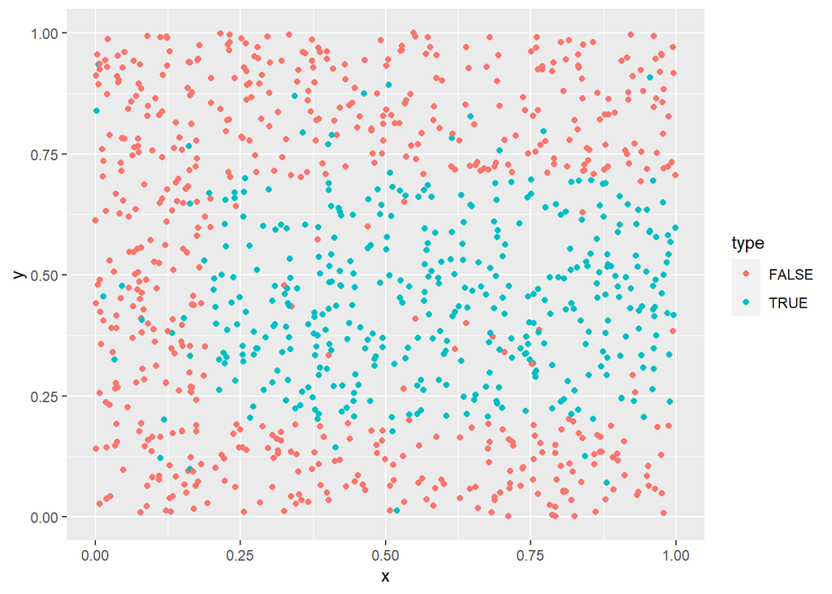

```r
rect <- ggplot(newData, aes(x=x, y=y, color=type)) + geom_point(shape=16)
#+ scale_color_hue(l=50)
rect
```

```r
geom_point(shape=16)
```

```
## geom_point: na.rm = FALSE
## stat_identity: na.rm = FALSE
## position_identity
```

Разделим данные на тренировочные и тестовые в соотншении (2/3) и (1/3). Оценим нейронную сеть с одним скрытым уровнем для тренировочных данных посмотрим на прогноз на тестовых данных.

```r
testInd = sample(N, trunc(N/3))
train = newData[-testInd,]
test = newData[testInd,]
set.seed(0)
nnFit <- neuralnet(type~x+y,
                   data = train, err.fct = "ce",
                   hidden = 3, threshold = 0.01,
                   linear.output=FALSE)
predict <- compute(nnFit,test[c("x","y")])$net.result > 0.5
conf <- table(pred = predict, true = test$type)
```

Важной характеристикой для получения информации о качестве классификации служит `confusion matrix`.

```r
conf
```

```
##        true
## pred    FALSE TRUE
##   FALSE   189   15
##   TRUE      9  120
```

```r
accuracy = (conf[1,1]+conf[2,2])/sum(conf)
accuracy
```

```
## [1] 0.9279279
```

```r
head(predict)
```

```
##      [,1]
## 148 FALSE
## 939 FALSE
## 290 FALSE
## 997 FALSE
## 133 FALSE
## 383  TRUE
```

Корреляция предсказанного типа с известным типом переменной в контрольной выборке

```r
cor(predict,test$type)
```

```
##           [,1]
## [1,] 0.8500429
```

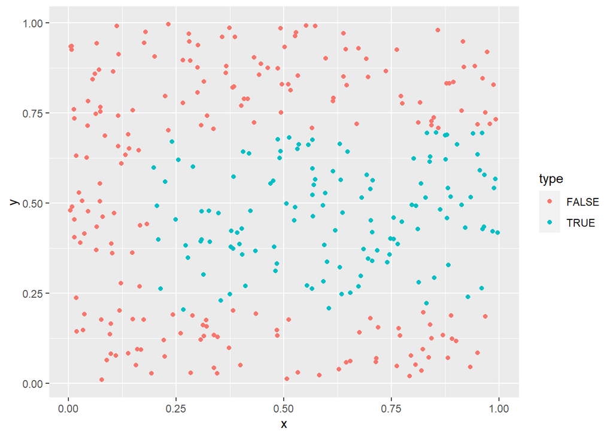

```r
test$type = predict
rect1 <- ggplot(test, aes(x=x, y=y, color=type)) + geom_point(shape=16)
rect1
```

# Библиотека Keras. Глубинное обучение(Deep Learning)

В последнее время очень популярной библиотекой для работы с нейронными сетями стала библиотека Keras — открытая нейросетевая библиотека, написанная на языке Python. Она представляет собой надстройку над фреймворками Deeplearning4j, TensorFlow и Theano.[1][2] Нацелена на оперативную работу с сетями глубинного обучения, при этом спроектирована так, чтобы быть компактной, модульной и расширяемой. Она была создана как часть исследовательских усилий проекта ONEIROS (англ. Open-ended Neuro-Electronic Intelligent Robot Operating System),[3] а ее основным автором и поддерживающим является Франсуа Шолле (фр. François Chollet), инженер Google.

Планировалось что Google будет поддерживать Keras в основной библиотеке TensorFlow, однако Шолле выделил Keras в отдельную надстройку, так как согласно концепции Keras является скорее интерфейсом, чем сквозной системой машинного обучения.

A теперь повторим некоторые примеры из лекции и сравним результаты работы библиотек keras и neuralnet.

## Задача регрессии. Прогноз результатов ЕГЭ.Библиотека keras

Прочитаем еще раз данные.

```r
library(keras)
filename<- './KP11.csv'
Students <-read.csv(file = filename,sep = ";")
DVIStud <-Students[Students$Summa> 0,]
head(DVIStud)
```

```
##   Code    Family       Name       Father Group Summa DVI EGE Task.1 X Task.2
## 1  105  АХМЕТОВА     ГЮЗЕЛЬ   РАФАЭЛЕВНА   102   489 100 100      3 1      3
## 3  234  САМСОНОВ     СЕРГЕЙ ВЛАДИМИРОВИЧ   110   495 100 100      3 1      3
## 4  358  СТЕПАНЮК АЛЕКСАНДРА     ОЛЕГОВНА   115   436  80  90      3 1      3
## 5  184 НИКИФОРОВ  ВЛАДИСЛАВ ВАЛЕНТИНОВИЧ   114   393  75  81      3 1      3
## 6  146  ХАБИРОВА    ЭЛЬВИРА   РАДМИРОВНА   103   435 100  85      2 1      3
## 8  319    КОЗЛОВ     НИКИТА ВЯЧЕСЛАВОВИЧ   117   448 100  85      3 1      3
##   X.1 Task.3а X.2 Task.3б X.3 Task.4 X.4 Task.5 X.5 Task.6 X.6 Task.7 X.7
## 1   1       3   1       3   1      3   1      3   1      3   1      2   1
## 3   1       3   1       3   1      3   1      3   1      2   1      0   0
## 4   1       3   1       3   1      3   1      3   1      2   1      0   0
## 5   1       3   1       3   1      2   1      3   1      3   1      2   1
## 6   1       3   1       3   1      2   1      3   1      2   1      3   1
## 8   1       3   1       3   1      3   1      2   1      3   1      3   1
##   Task.8 X.8 SumKP1 AlgKP1 X.A.KP1 GeomKP1 X.Г.KP1
## 1      3   1     26      6  100.0%       3  100.0%
## 3      3   1     23      6  100.0%       2   66.7%
## 4      3   1     23      6  100.0%       2   66.7%
## 5      1   0     23      6  100.0%       2   66.7%
## 6      2   1     23      6  100.0%       3  100.0%
## 8      0   0     23      6  100.0%       2   66.7%
```

Аналогичо подготовим тренировочные и тестовые данные.

```r
set.seed(100)
d = sort(sample(nrow(DVIStud), nrow(DVIStud)*.9))
train <- DVIStud[d,]
train <- as.data.frame(train)
test<-DVIStud[-d,]
egada<-data.frame(x1=train$AlgKP1/max(train$AlgKP1),x2=train$GeomKP1/max(train$GeomKP1),x3 = train$Summa/max(train$Summa),x4=train$DVI/max(train$DVI),y=train$EGE/max(train$EGE))
testda<-data.frame(x1=test$AlgKP1/max(test$AlgKP1),x2=test$GeomKP1/max(test$GeomKP1),x3 = test$Summa/max(test$Summa),x4= test$DVI/max(test$DVI))
```

Далее следует разнести входные и выходные данные в разные переменные.

```r
x_train <- egada[,1:3]
y_train <- egada[,4]
x_test <- testda[,1:3]
y_test <- testda[,4]
```

Важный момент !!! В keras данные на вход должны идти как вектора или матрицы, а не data.frame.

```r
x_train <- as.matrix(x_train)
y_train <- as.matrix(y_train)
x_test <- as.matrix(x_test)
y_test <- as.matrix(y_test)
```

Создаем переменную `model`, в которой зададим архитектуру будущей сети.

```r
model <- keras_model_sequential()
```

```
## Loaded Tensorflow version 2.4.1
```

```r
model %>%
  layer_dense(units = 32, input_shape = c(3)) %>%
  layer_activation('relu') %>%
  layer_dense(units = 1)
```

```r
  summary(model)
```

```
## Model: "sequential"
## ________________________________________________________________________________
## Layer (type)                        Output Shape                    Param #
## ================================================================================
## dense_1 (Dense)                     (None, 32)                      128
## ________________________________________________________________________________
## activation (Activation)             (None, 32)                      0
## ________________________________________________________________________________
## dense (Dense)                       (None, 1)                       33
## ================================================================================
## Total params: 161
## Trainable params: 161
## Non-trainable params: 0
## ________________________________________________________________________________
```

Начальными значениями для весов $w_i,i =1,...,161$ берутся по умолчанию равномерно распределенные случайные числа (это тоже параметр, который можно менять, по умолчанию kernel_initializer = “glorot_uniform”). Следующий этап задание функции, по которой будут вычисляться потери и функции, показывающей качество обучения, а также тип оптимизатора. И последующая компиляция модели.

```r
model %>% compile(
  loss = 'mse',
  optimizer = 'adam',
  metrics = c('mae')
)
```

Функция потерь выберем `mse` - mean squared error (средняя сумма квадратов ошибок предсказания) это обычная функция для задач регрессии, а в качестве метрики оценки качества `mае` - mean absolute error (средний модуль ошибки предсказания).

Тип оптимизатора весов `adam` - an algorithm for first-order gradient-based optimization of stochastic objective functions, based on adaptive estimates of lower-order moments. Возможны и другие типы минимизаторов, например, sgd-Stochastic gradient descent.

Опять же это все параметры, с которыми следует играть, добиваясь лучших результатов при обучении и предсказании.

Пришло время обучить нашу сеть.

```r
history <- model %>% fit(
  x_train, y_train,
  epochs = 60, batch_size = 10,
  validation_split = 0.2
)
```

batch_size - обозначает размер подмножества обучающей выборки (например, 100 из 1000), который будет использоваться для обучения сети в процессе ее обучения. Каждая часть выборки обучает сеть в последовательном порядке с учетом обновленных весов, поступающих от обучения предыдущего подмножества.

epochs = 60 - количество эпох или попыток минимизации

validation_split - это число от 0 до 1 - доля данных, используемых при валидации результата каждой эпохи. О том как менялись результаты обучения от эпохи к эпохе наглядно демонстрируют следующие графики

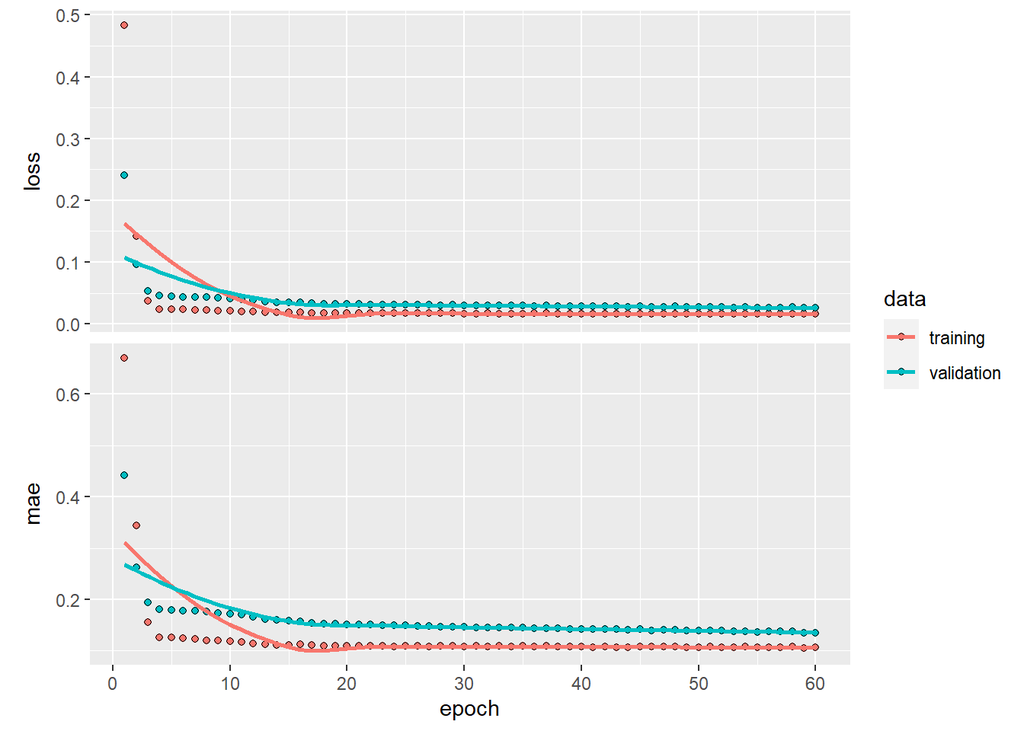

```r
plot(history)
```

Теперь посмотрим на результаты обучения на тренировочной выборке и результаты предсказания на тестовой выборке

```r
model %>% evaluate(x_train, y_train)
```

```
##       loss        mae
## 0.01808504 0.11296409
```

```r
model %>% evaluate(x_test, y_test)
```

```
##       loss        mae
## 0.01837473 0.10819294
```

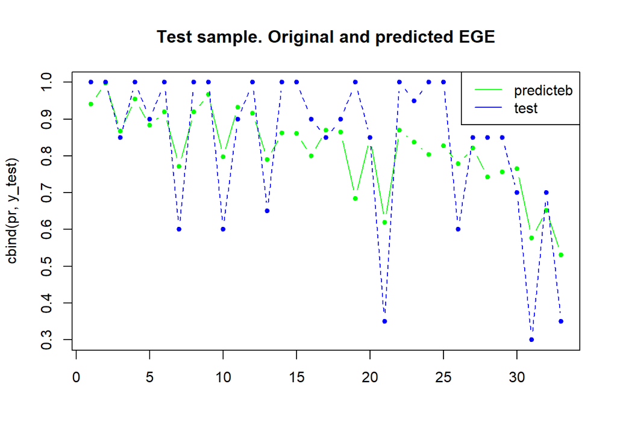

```r
pr <-as.vector(model %>% predict(x_test))
prtrain <-as.vector(model %>% predict(x_train))

matplot(cbind(pr,y_test),main = 'Test sample. Original and predicted EGE',type='b',pch=20,col=c('green','blue'))
legend('topright',c('predicteb','test'),col=c('green','blue'),lty=c(1,1))
```

```r
  cor(pr,y_test)
```

```
##           [,1]
## [1,] 0.7955234
```

## Карты Кохонена

Самоорганизу́ющаяся ка́рта Ко́хонена (англ. Self-organizing map — SOM) — нейронная сеть с обучением без учителя, выполняющая задачу визуализации и кластеризации. Идея сети предложена финским учёным Т. Кохоненом. Является методом проецирования многомерного пространства в пространство с более низкой размерностью (чаще всего, двумерное)

Нейронная сеть Кохонена преимущественно используется для решения задач кластеризации, то есть объединения неких объектов в отдельные группы (кластеры). Решение о попадании объекта в тот или иной кластер принимается на основе значений его признаков, которые являются входными данными данного класса нейросетей.

Самоорганизующаяся карта состоит из компонентов, называемых узлами или нейронами. Их количество задаётся аналитиком. Каждый из узлов описывается двумя векторами. Первый — т. н. вектор веса m, имеющий такую же размерность, что и входные данные. Второй — вектор r, представляющий собой координаты узла на карте. Карта Кохонена визуально отображается с помощью ячеек прямоугольной или шестиугольной формы; последняя применяется в R, поскольку в этом случае расстояния между центрами смежных ячеек одинаковы, что повышает корректность визуализации карты.

Число входных нейронов четко равно количеству признаков объектов, а количество выходных нейронов – числу кластеров. В работе сети действует принцип «победитель получает все», то есть наибольший выходной сигнал трансформируется в единичный, а остальные выходы обнуляются. Таким образом, подавая признаки некоторого объекта на вход, на выходе мы получим ряд нулевых значений, и лишь у одного нейрона значение будет равно единице. Это и сигнализирует о том, что объект отнесен к данному кластеру.

Пример построения карт Кохонена рассмотрим на примере набора акций финансовых инструментов России

```r
library(kohonen)
```

```r
indata <- read.csv("./micexmarket1.csv",header = TRUE)
head(indata)
```

```
##   п.ї239x12   GAZP  GMK LKOH   ROSN  RTKM   SBER   SNGZ     VTB RUSGIDRO PLZL
## 1  03/10/17 128.78 8855 3028 315.00 74.90 157.50 28.200 0.06505   0.9335 4450
## 2  03/13/17 129.93 8965 3051 318.25 76.41 158.92 28.350 0.06526   0.9321 4450
## 3  03/14/17 128.80 9097 3080 315.40 77.06 157.42 28.655 0.06506   0.9400 4455
## 4  03/15/17 127.60 9057 3088 314.70 76.64 156.20 28.435 0.06514   0.9400 4476
## 5  03/16/17 128.05 9054 3095 313.95 76.20 158.35 28.650 0.06550   0.9525 4400
## 6  03/17/17 128.94 9169 3130 314.45 75.00 161.15 28.935 0.06625   0.9580 4447
##       RTS    Rubl
## 1 1055.93 58.6750
## 2 1069.14 58.9925
## 3 1063.69 59.5325
## 4 1062.61 59.1450
## 5 1096.29 57.9000
## 6 1111.89 57.6350
```

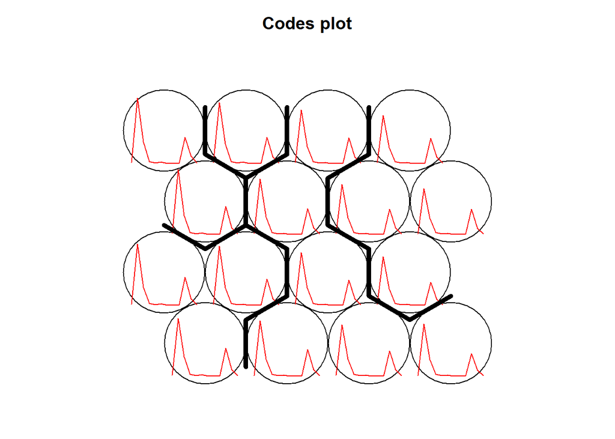

```r
data <- indata[,2:dim(indata)[2]]
dimx <- 4
dimy <- 4
nClust <- 4
som <- supersom(as.matrix(data), grid = somgrid(dimx,dimy, "hexagonal"))
som.hc <- cutree(hclust(dist(som$codes[[1]])), nClust)
        plot(som,"codes",codeRendering ="lines")
        add.cluster.boundaries(som, som.hc)
```

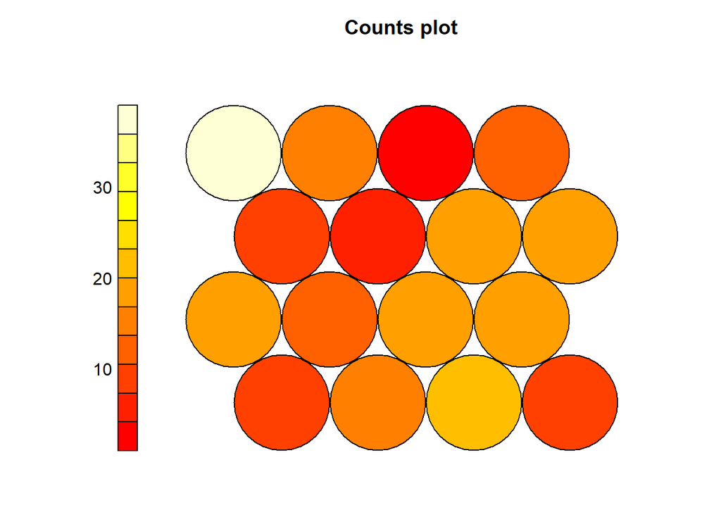

```r
        plot(som,"counts")
```

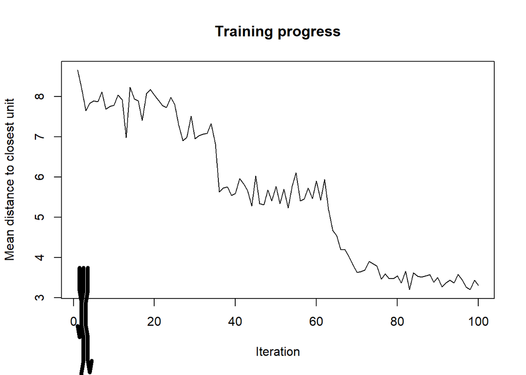

```r
        plot(som,"changes")
#        plot(som,"quality")
        add.cluster.boundaries(som, som.hc)
```

Посмотрим центры узлов

```r
som$codes
```

```
## [[1]]
##         GAZP       GMK     LKOH     ROSN     RTKM     SBER     SNGZ        VTB
## V1  133.4103 10087.629 3359.118 294.1134 64.00998 224.1345 27.84362 0.05137673
## V2  120.4913  9672.613 2944.253 311.5620 66.88807 186.4186 27.78114 0.06248914
## V3  126.0773  8940.638 2972.887 318.4545 74.29595 161.6131 28.17598 0.06470639
## V4  118.5722  9084.441 2895.091 313.7997 65.68491 169.6679 27.10373 0.06148645
## V5  128.4299 10658.226 3150.728 313.1449 67.43966 208.0453 29.35883 0.05765701
## V6  124.1415 10291.205 3031.547 317.0922 67.61289 193.7614 29.42864 0.06107051
## V7  124.4233  9147.192 3000.641 313.9931 72.27331 169.0845 28.26399 0.06375661
## V8  121.6379  8472.852 2872.023 318.3010 67.29593 157.1777 26.43943 0.06383814
## V9  130.1956 11363.340 3277.874 323.5136 70.09268 209.3038 29.84089 0.05927493
## V10 122.7874  9672.849 3035.935 320.7801 68.92706 191.3295 29.17782 0.06182844
## V11 127.2338  8676.673 2853.328 314.4136 73.02278 162.5985 27.41763 0.06487046
## V12 118.9045  7989.127 2754.077 310.7683 70.71890 149.1233 26.48208 0.06446731
## V13 143.2625 11425.627 3764.345 330.5732 66.14957 259.0267 29.11667 0.05014611
## V14 133.5850 10647.524 3403.916 297.8768 64.17717 228.1948 28.45590 0.04842933
## V15 124.8768  9370.798 2982.139 307.9224 69.36637 181.8649 27.54170 0.06047491
## V16 124.9858  8336.485 2823.840 309.5286 72.87664 163.6176 27.89115 0.06596485
##      RUSGIDRO     PLZL      RTS     Rubl
## V1  0.8132426 4867.225 1134.224 58.72937
## V2  0.8215381 4645.391 1112.120 57.72792
## V3  0.9030391 4406.592 1089.412 57.46510
## V4  0.7762517 3940.687 1026.663 60.01275
## V5  0.8364677 4865.924 1136.502 58.31712
## V6  0.8481708 4583.002 1134.656 57.70520
## V7  0.9027360 4366.458 1089.977 58.11663
## V8  0.7970641 3968.374 1018.516 59.65184
## V9  0.8311628 4903.562 1138.528 59.02627
## V10 0.8254759 4432.238 1128.138 57.69103
## V11 0.8739191 4396.530 1086.123 57.05713
## V12 0.7964921 4349.760 1022.068 57.71241
## V13 0.7651069 4525.351 1267.752 56.70147
## V14 0.7688596 4546.284 1150.653 58.36343
## V15 0.8507976 4478.849 1097.629 57.85332
## V16 0.8310890 4425.199 1074.675 57.19930
```

Посмотрим какие узлы принадлежат к какому кластеру

```r
som.hc
```

```
##  V1  V2  V3  V4  V5  V6  V7  V8  V9 V10 V11 V12 V13 V14 V15 V16
##   1   2   2   2   1   1   2   3   4   2   3   3   4   1   2   3
```

Среднее значение первого кластера

```r
Cluster1.code<-apply(subset(som$codes[[1]],som.hc==1),1 ,mean)
Cluster1.code
```

```
##       V1       V5       V6      V14
## 1687.608 1718.084 1652.588 1713.321
```

Средние цены инструментов в первом кластере

```r
Cluster1.code<-apply(subset(som$codes[[1]],som.hc==1),2 ,mean)
Cluster1.code
```

```
##         GAZP          GMK         LKOH         ROSN         RTKM         SBER
## 1.298917e+02 1.042115e+04 3.236327e+03 3.055568e+02 6.580992e+01 2.135340e+02
##         SNGZ          VTB     RUSGIDRO         PLZL          RTS         Rubl
## 2.877175e+01 5.463339e-02 8.166852e-01 4.715609e+03 1.139009e+03 5.827878e+01
```

Среднее значение второго кластера

```r
Cluster2.code<-apply(subset(som$codes[[1]],som.hc==2),1 ,mean)
Cluster2.code
```

```
##       V2       V3       V4       V7      V10      V15
## 1595.511 1514.715 1475.213 1530.949 1588.395 1558.313
```

Средние цены инструментов во втором кластере

```r
Cluster2.code<-apply(subset(som$codes[[1]],som.hc==2),2 ,mean)
Cluster2.code
```

```
##         GAZP          GMK         LKOH         ROSN         RTKM         SBER
## 1.228714e+02 9.314755e+03 2.971825e+03 3.144186e+02 6.957261e+01 1.766631e+02
##         SNGZ          VTB     RUSGIDRO         PLZL          RTS         Rubl
## 2.800739e+01 6.245699e-02 8.466397e-01 4.378369e+03 1.090657e+03 5.814446e+01
```

```r
Cluster3.code<-apply(subset(som$codes[[1]],som.hc=3),1 ,mean)
Cluster3.code
```

```
##       V1       V2       V3       V4       V5       V6       V7       V8
## 1687.608 1595.511 1514.715 1475.213 1718.084 1652.588 1530.949 1423.594
##       V9      V10      V11      V12      V13      V14      V15      V16
## 1792.181 1588.395 1481.278 1404.134 1822.393 1713.321 1558.313 1451.433
```

Средние цены инструментов в третьем кластере

```r
Cluster.code<-apply(subset(som$codes[[1]],som.hc==3),2 ,mean)
Cluster.code
```

```
##         GAZP          GMK         LKOH         ROSN         RTKM         SBER
## 1.231905e+02 8.368784e+03 2.825817e+03 3.132529e+02 7.097856e+01 1.581293e+02
##         SNGZ          VTB     RUSGIDRO         PLZL          RTS         Rubl
## 2.705757e+01 6.478519e-02 8.246411e-01 4.284966e+03 1.050346e+03 5.790517e+01
```

Посмотрим в каком узле находится многомерный процесс акций в каждый момент времени

```r
(clusters<-som$unit.classif)
```

```
##   [1]  3  3  7  7  7  7  3  7  7  7  7  3  3  3  3  3  3  3  7  7  3  3  3  3 11
##  [26] 11  3 11 11 11 11 11  3  3 11 11 11 11 11 11 11 16 16 11 16 16 16 16 16 16
##  [51] 16 16 16 12 12 12 12 12 12 12 12 12 12 12 12 12  8 16 16 12 12 12 12 12  8
##  [76] 12  8  8  8  8  8  8  8  8  8  8  8  8  8  8  8  8  8  4  4  4  4  4  4  4
## [101]  4  4  4  7  3  7  3 11 11  3  3  7  7  7  7  7 15  2  2  2  2  2  2  2  2
## [126]  2  2  2  2  2  2  2  2 10 10 10 10 10 10  6  6  6  6  6  6  6  6  6  5  5
## [151]  5  5  5  5  5  6  6  5  5  5  9  9  9  9  9  9  9  9  9  5  9  5  5  5  5
## [176]  5  5  1  1  1  1  1  1  1  1  1 14 14 14 14 14 14 14 14 14 14 14 14 14 14
## [201] 13 13 13 13 13 13 13 13 13 13 13 13 13 13 13 13 13 13 13 13 13 13 13 13 13
## [226] 13 13 14 13 13 13 13 13 13 13 13 13 13 13 13
```

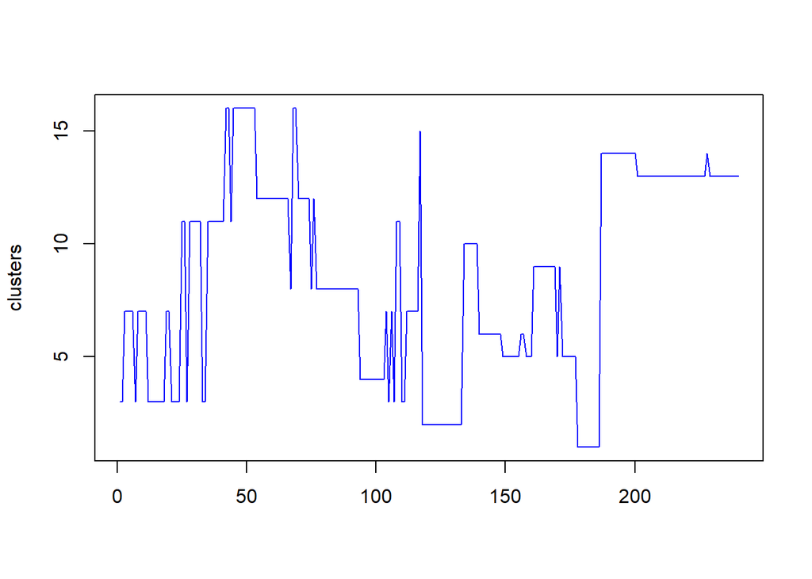

```r
matplot(clusters,type='l',col = 'blue')
```

```r
library(markovchain)
hmm <- markovchainFit(data = clusters, method = "mle", name = "Alofi")
```

Матрица вероятностей перехода из ячейки в ячейку за один шаг процесса

```r
(trmatr <- hmm$estimate@transitionMatrix)
```

```
##             1        10         11         12        13         14         15
## 1  0.88888889 0.0000000 0.00000000 0.00000000 0.0000000 0.11111111 0.00000000
## 10 0.00000000 0.8333333 0.00000000 0.00000000 0.0000000 0.00000000 0.00000000
## 11 0.00000000 0.0000000 0.70588235 0.00000000 0.0000000 0.00000000 0.00000000
## 12 0.00000000 0.0000000 0.00000000 0.84210526 0.0000000 0.00000000 0.00000000
## 13 0.00000000 0.0000000 0.00000000 0.00000000 0.9736842 0.02631579 0.00000000
## 14 0.00000000 0.0000000 0.00000000 0.00000000 0.1333333 0.86666667 0.00000000
## 15 0.00000000 0.0000000 0.00000000 0.00000000 0.0000000 0.00000000 0.00000000
## 16 0.00000000 0.0000000 0.07692308 0.15384615 0.0000000 0.00000000 0.00000000
## 2  0.00000000 0.0625000 0.00000000 0.00000000 0.0000000 0.00000000 0.00000000
## 3  0.00000000 0.0000000 0.19047619 0.00000000 0.0000000 0.00000000 0.00000000
## 4  0.00000000 0.0000000 0.00000000 0.00000000 0.0000000 0.00000000 0.00000000
## 5  0.05882353 0.0000000 0.00000000 0.00000000 0.0000000 0.00000000 0.00000000
## 6  0.00000000 0.0000000 0.00000000 0.00000000 0.0000000 0.00000000 0.00000000
## 7  0.00000000 0.0000000 0.00000000 0.00000000 0.0000000 0.00000000 0.05882353
```

[output cut: 36 more lines]